# Допущения модели линейной регрессии и линеаризация зависимостей

## Нелинейность

Если между переменными $x$ и $y$ есть нелинейная зависимость, то и модель должна быть нелинейной. Для построения такой модели можно преобразовать зависимую переменную или предиктор, либо добавить в модель члены более высоких порядков - например, квадратичные. В этом случае придется использовать модель множественной регрессии.

```r
m_poly <- lm(y_nonlin ~ x + I(x^2))
```

Для добавления квадратичного члена $x^2$ необходимо заключить его в функцию `I()` (identity), т.к. символ `^` имеет специальное назначение в синтаксисе формул R.

```r
coef(m_poly)
```

```
## (Intercept)           x      I(x^2)
##       5.233       0.930       0.504
```

Формула для квадратичной модели:

$$\hat{y} = 5.233 + 0.930 x + 0.504 x^2$$

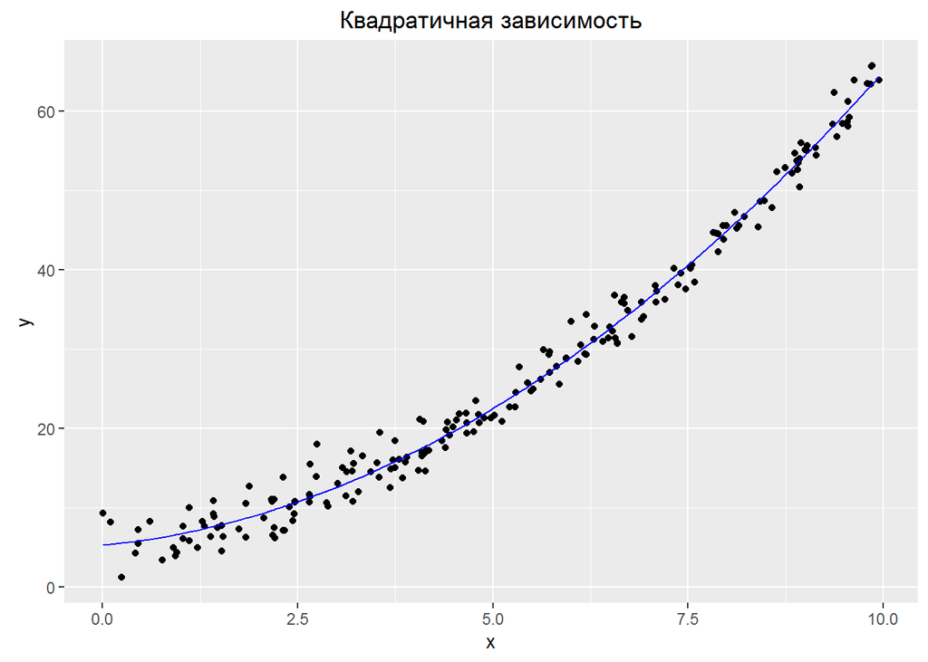

```r
ggplot(data = add_predictions(tibble(x, y_nonlin), m_poly),
      mapping = aes(x)) +
      geom_point(aes(y = y_nonlin)) +
      geom_line(aes(y = pred), colour='blue') +
  labs(title = 'Квадратичная зависимость', y = 'y')
```

Диагностика остатков для квадратичной модели

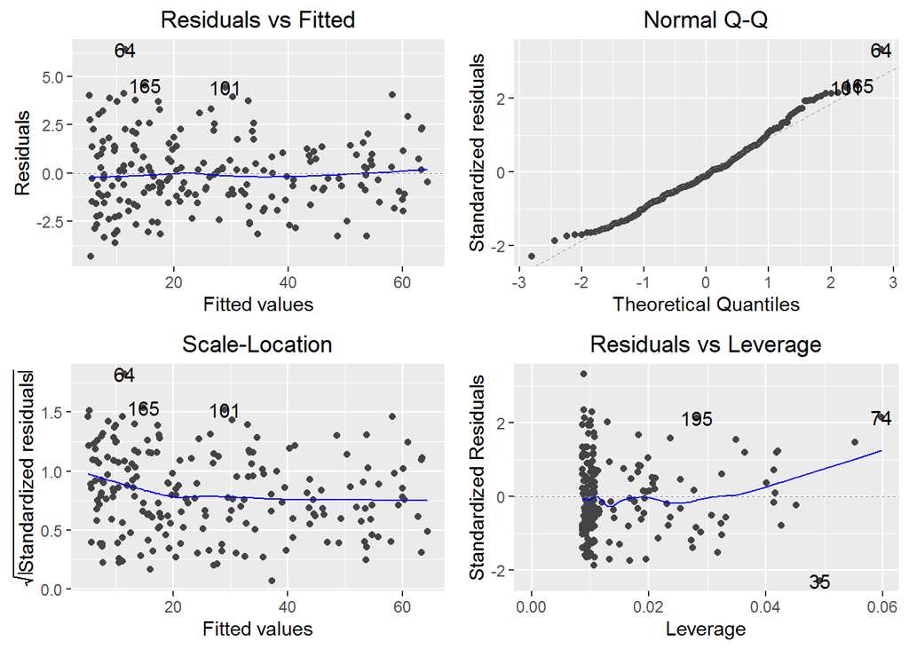

```r
autoplot(m_poly)
```

Теперь графики не демонстрируют нарушений предположений линейной модели.

## Степенные преобразования

Как и в случае временных рядов, к данным для построения регрессионных моделей можно применять степенные преобразования (power transformations), обобщением которых является преобразование Бокса-Кокса:

$$y \to y ^\lambda$$

Наиболее часто используемые значения параметра степени преобразования $\lambda$ приведены в таблице.

| $\lambda$ | Преобразование |
| --- | --- |
| $-2$ | $1/y^2$ |
| $-1$ | $1/y$ |
| $-0.5$ | $1/\sqrt{y}$ |
| $0$ | $\log{y}$ |
| $0.5$ | $\sqrt{y}$ |
| $1$ | Нет преобразования |
| $2$ | $y^2$ |

Для подбора степени преобразования данных для регрессии можно использовать функцию `car::powerTransform()`. Эта функция подбирает параметр $\lambda$ таким образом, чтобы распределение остатков линейной модели в результате было наиболее близко к нормальному.

```r
# Подбор степени для модели с гетероскедастичностью
t1 <- powerTransform(y_hetero ~ x)
coef(t1)
```

```
##    Y1
## -0.27
```

Степень для данных с гетероскедастичностью оказалась близкой к $-0.25$, что эквивалентно:
$$\frac{1}{\sqrt[4]{y}}.$$

```r
m_ht <- lm(y_hetero^-0.25 ~ x)
coef(m_ht)
```

```
## (Intercept)           x
##      0.6427     -0.0141
```

Диагностика остатков:

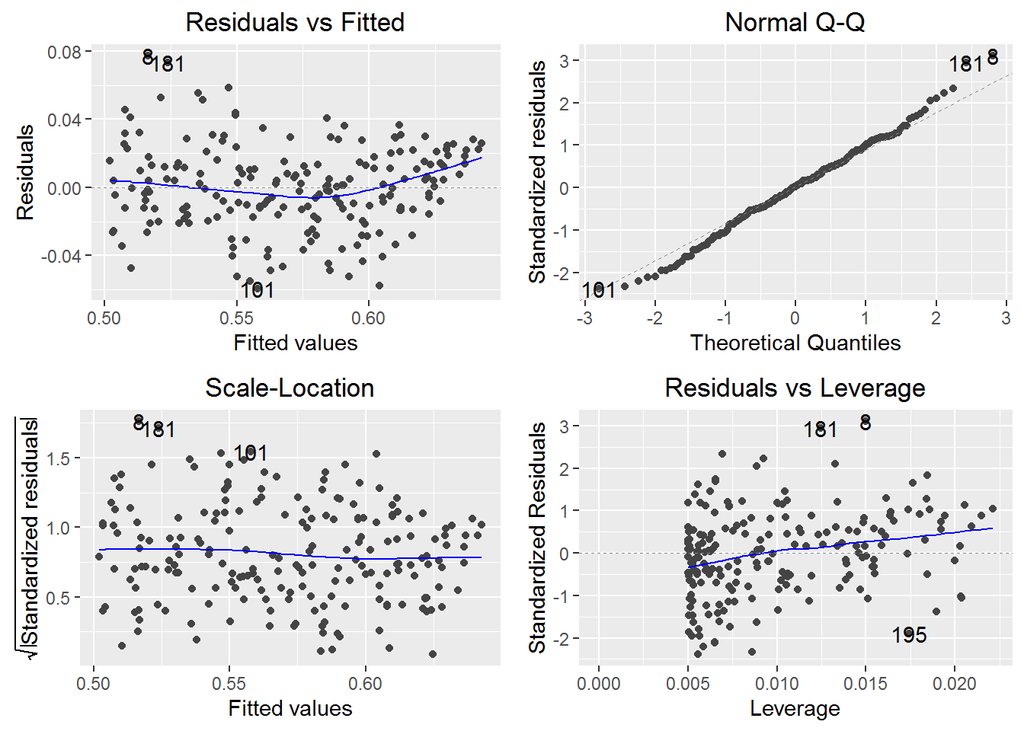

```r
autoplot(m_ht)
```

Рассмотрим данные с нелинейной зависимостью.

```r
## Подбор степени для нелинейной модели
t2 <- powerTransform(y_nonlin ~ x)
coef(t2)
```

```
##    Y1
## 0.497
```

Для нелинейной модели степень преобразования близка к $0.5$, т.е. $\sqrt{y}$.

```r
m_nlt <- lm(sqrt(y_nonlin) ~ x)
coef(m_nlt)
```

```
## (Intercept)           x
##       1.766       0.613
```

Уравнение регрессии:

$$\sqrt{\hat{y}} = 1.766 + 0.613 \cdot x$$

или:

$$\hat{y} = (1.766 + 0.613 \cdot x)^2$$

Диагностика остатков для этой модели:

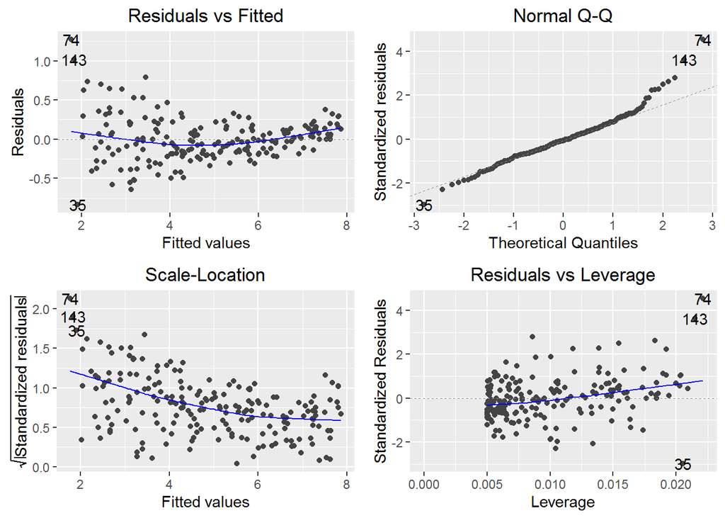

```r
autoplot(m_nlt)
```

По графикам видно, что проблемы устранены не в полной мере.

## Как делать прогноз при использовании преобразований

### Если в модель включены нелинейные члены

В случае, когда преобразования объясняющей переменной или члены более высоких порядков были заданы непосредственно в формуле внутри `lm()`, то все необходимые преобразования данных R выполнит автоматически.

Рассмотрим пример с полиномиальной регрессией

Формула и коэффициенты модели:

```r
formula(m_poly)
```

```
## y_nonlin ~ x + I(x^2)
```

```r
coef(m_poly)
```

```
## (Intercept)           x      I(x^2)
##       5.233       0.930       0.504
```

Точечный прогноз будет получен автоматически, например, с помощью функции `add_predictions()`. Интервальный прогноз можно получить с помощью функции `predict()` и добавить в таблицу данных для визуализации.

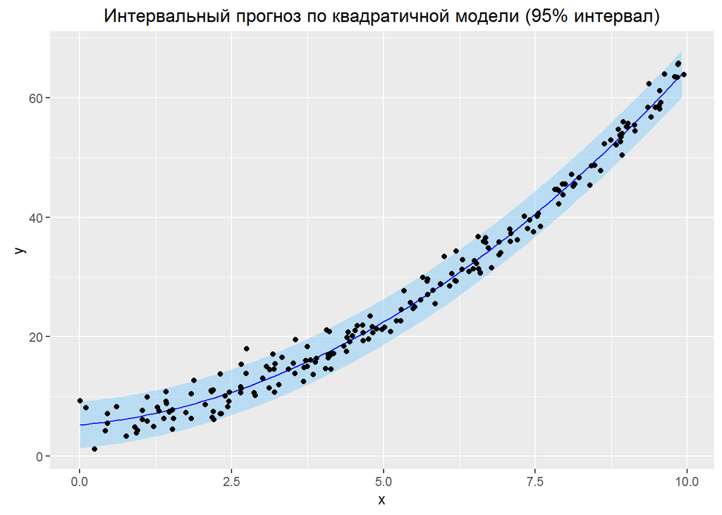

```r
# Создаем точки для получения нового прогноза
newdata_nl <- data.frame(x = seq_range(x, by = 0.1))

# Интервальный прогноз:
pred_nl <- predict(m_poly, newdata = newdata_nl,
                   interval = 'prediction',
                   level = .95)

# Соединяем все в одну таблицу:
newdata_nl <- bind_cols(newdata_nl, as.data.frame(pred_nl))

# График
ggplot(data = newdata_nl,
       mapping = aes(x)) +
  geom_ribbon(aes(ymin=lwr, ymax=upr),
              fill='lightskyblue', alpha=1/2) +
  geom_line(aes(y = fit), colour='blue') +
  geom_point(data= tibble (x=x, y=y_nonlin), aes(x, y)) +
  labs(title='Интервальный прогноз по квадратичной модели (95% интервал)',
       y = 'y')
```

### Если преобразование применялось к зависимой переменной

В случае, когда преобразование применялось к зависимой переменной, линейная модель предсказывает преобразованное значение выходной переменной. Его нужно привести к исходной шкале путем обратного преобразования.

Например, если при моделировании использовалось преобразование:
$$w = 1/\sqrt[4]{y},$$

то необходимо выполнить обратное преобразование прогноза и границ доверительного интервала по формуле:

$$\hat{y} = (1/w)^4.$$

Формула и коэффициенты модели с преобразованным $y$:

```r
formula(m_ht)
```

```
## y_hetero^-0.25 ~ x
```

```r
coef(m_ht)
```

```
## (Intercept)           x
##      0.6427     -0.0141
```

Вычисление прогноза:

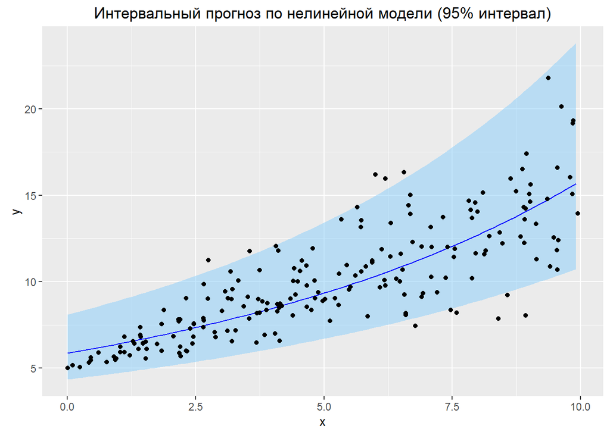

```r
# Создаем точки для получения нового прогноза
newdata_ht <- data.frame(x = seq_range(x, by = 0.1))

# Интервальный прогноз:
pred_ht_transformed <- predict(m_ht, newdata = newdata_ht,
                   interval = 'prediction',
                   level = .95)

# Обратное преобразование:
pred_ht <- pred_ht_transformed^(-4)

# Соединяем все в одну таблицу:
newdata_ht <- bind_cols(newdata_ht, as.data.frame(pred_ht))

# График
ggplot(data = newdata_ht,
       mapping = aes(x)) +
  geom_ribbon(aes(ymin=lwr, ymax=upr),
              fill='lightskyblue', alpha=1/2) +
  geom_line(aes(y = fit), colour='blue') +
  geom_point(data= tibble (x=x, y=y_hetero), aes(x, y)) +
  labs(title='Интервальный прогноз по нелинейной модели (95% интервал)',
       y = 'y')
```

Границы доверительного интервала расходятся, т.к. к ним применили нелинейное преобразование. Это означает, что уровень неопределенности возрастает при увеличении $y$. Этого следовало ожидать, т.к. гетероскедастичность - по определению рост дисперсии.

# Приложения

## Интерпретация коэффициентов модели при логарифмическом преобразовании данных

Логарифмические преобразования широко применяются для линеаризации зависимостей в данных и уменьшения гетероскедастичности. При использовании логарифмических и полулогарифмических моделей коэффициенты имеют специальную интерпретацию, приведенную в таблице

| Уравнение | Интерпретация углового коэффициента $b_1$ |
| --- | --- |
| $y = b_0 + b_1 x + e$ | При увеличении $x$ на $1$, $y$ изменится на $b_1$ |
| $\log y = b_0 + b_1 x + e$ | При увеличении $x$ на $1$, $y$ изменится на $100 b_1 \%$ |
| $y = b_0 + b_1 \log x + e$ | При увеличении $x$ на $1 \%$, $y$ изменится на $b_1 / 100$ |
| $\log y = b_0 + b_1 \log x + e$ | При увеличении $x$ на $1\%$, $y$ изменится на $b_1\%$ |

Модель 4 называется логарифмической, модели 2 и 3 - полу-логарифмическими (semi-log). В английском языке для обозначения перечисленных типов моделей моделей используются также термины: level-level, log-level, level-log и log-log.

**Примечание**: лоагрифмическая модель (log-log) позволяет оценить **эластичность** $y$ к $x$, т.е. процентное изменение $y$ при изменении на $1\%$ переменной $x$.

## Пример поиска влиятельных наблюдений

Добавим в исходные данные несколько выбросов:

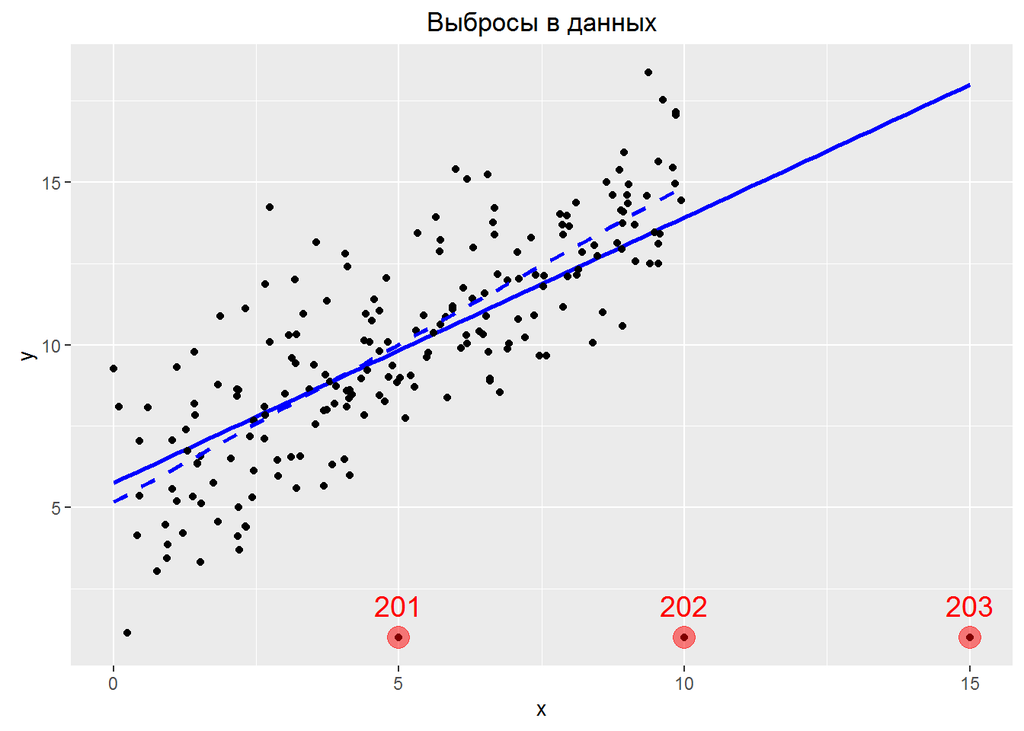

```r
data_original <- tibble(x, y)

data_outliers <-
  tribble(
    ~x, ~y,
    5,  1,
    10, 1,
    15, 1
  )

data_combined <- bind_rows(data_original, data_outliers)

ggplot(data_combined, aes(x, y)) +
  geom_smooth(method = 'lm', colour = 'blue', se = F) +
  geom_point() +
  geom_smooth(data = data_original,
              method = 'lm', color = 'blue', se = F, linetype = 'dashed') +
  geom_point(data = data_outliers,
             mapping = aes(x, y),
             color = 'red',
             size = 5,
             alpha = 0.5) +
  geom_text(data = data_outliers,
             mapping = aes(x, y,
                           label = nrow(data_original) + 1:nrow(data_outliers)),
             color = 'red',size = 5,
            vjust = -1) +
  labs(title = 'Выбросы в данных')
```

Выбросы на диагностических графиках

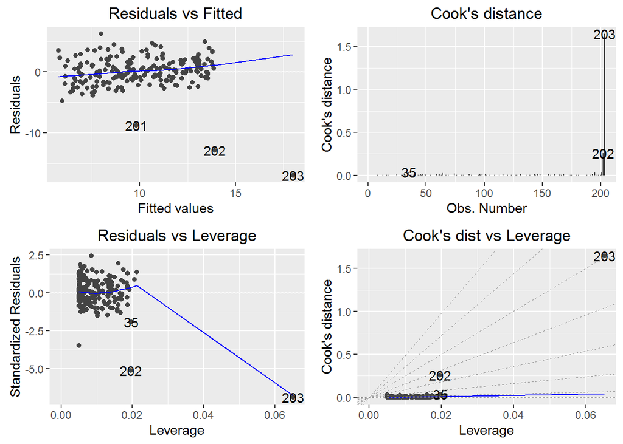

```r
# Построение модели
m_o <- lm(y ~ x, data = data_combined)

# Диагностические графики

autoplot(m_o, which = c(1, 4:6))
```

Для всех добавленных точек-выбросов остатки большие. Однако наблюдение **#201** $(5, 1)$ имеет небольшой леверидж, т.к. оно находится вблизи среднего значения $x$ и вокруг нее много других точек. Поэтому влияние этого наблюдения на модель небольшое: положение прямой в этой области определяется по большому числу наблюдений. Это наблюдение не помечено как влиятельное.

Наблюдение**#202** $(10, 1)$ находится дальше от центра, а ошибка модели в этой точке еще выше. Наибольшее удаление от других наблюдений имеет точка **#203** $(15, 1)$. У нее нет соседних точек, поэтому положение прямой в этой области определяется только на основе этого наблюдения. По этой причине данное наблюдение имеет большой леверидж и большое расстояние Кука. Некоторые источники рекомендуют использовать в качестве порога значение расстояния Кука $D=1$, другие - более консервативную границу $4/n$, где $n$ - число наблюдений в выборке.